# WarwickLove

Aksara Iam

9/26/2021

# 1 Intro

WarwickLove is an online community for Warwick Students. With more than 7,000 likes and followers, it is the place where people express their idea and confession (Love?) anonymously. In this project, we try to discover what the community of students from the University of Warwick is most interested in, excited, and worried about by analysing the posts from the Facebook page.

# 2 Data Import

- Data is fetched and parsed into a data frame from the Facebook page called ‘WarwickFessions’ (@warwickloveee), using Python library [facebook-scraper].

```r
files <- list.files(pattern = "*.csv", recursive = TRUE)
```

- Creating a dataframe

```r
# read files
df_1 <- read_csv(files[2])
```

# 3 Data Wrangling

```r
# create a function for text cleaning
cleanse_text = function(c) {
  c = iconv(c)
  c = gsub("[[:punct:][:blank:]]+", " ", c)
  c = stringr::str_replace_all(c, "\r", "")
  c = stringr::str_replace_all(c, "\n", "")
  c = trimws(c)
  return(c)
}

# create a function extracting only numbers
numextract <- function(string){
  str_extract(string, "\\-*\\d+\\.*\\d*")
}
```

- Let’s convert post_id to string type.

```r
df_1$post_id = as.character(df_1$post_id)
```

- Next, we drop posts that do not contain any texts and create a new feature called ‘text_char’ extracting a number of characters for each post.

```r
# drop text_na
df_1 = df_1 %>% drop_na(text, post_text)

# count number of characters
df_1 = df_1 %>% mutate(text_char = stringr::str_count(text), post_text_char = str_count(post_text))

# check if they're the same
sum(df_1$text_char == df_1$post_text_char)
```

```
## [1] 5252
```

```r
# check where they're not equal
View(df_1[!(df_1$text_char == df_1$post_text_char),])
```

## 3.1 Null values

- Let’s check missing values and remove them if any.

```r
# check null values
nacols = which(colSums(is.na(df_1)) > 0)
sort(colSums(sapply(df_1[nacols], is.na)), decreasing = TRUE)
```

```
##                  video video_duration_seconds           video_height
##                   5260                   5260                   5260
##               video_id          video_quality          video_size_MB
##                   5260                   5260                   5260
##        video_thumbnail          video_watches            video_width
##                   5260                   5260                   5260
##              factcheck         shared_post_id            shared_time
##                   5260                   5260                   5260
##         shared_user_id        shared_username        shared_post_url
##                   5260                   5260                   5260
##          comments_full            shared_text                   link
##                   5260                   5252                   5220
##               image_id                  image       image_lowquality
##                   5029                   5024                   5021
##               reactors              w3_fb_url              reactions
##                   1472                   1472                   1472
##         reaction_count                  likes
##                   1472                    553
```

```r
# NULL 721 values
nacols_all = which(colSums(is.na(df_1)) > 5000)

# subsetting
df_2 = df_1[,-c(nacols_all)]
```

## 3.2 Images Variables

- Some posts were posted with images, hence we create a variable named ‘image_group’.

```r
# have image?
df_2 = df_2 %>% mutate(image_group = if_else(str_count(images) > 2, 1,0)) %>% replace_na(list(image_group = 0))

df_3 = df_2 %>% select(post_id, text,time,image_group,likes,comments,shares,user_id,reactions,reaction_count,text_char)
```

## 3.3 Time-related Variables

- Let’s retrieve time variables such as year, month, date, hour.

```r
# time
df_3 = df_3 %>%
  #mutate(time = ymd_hms(time, tz = "Europe/London")) %>%
  mutate(year = strftime(time, format = "%Y"),
         month = strftime(time, format = "%m"),
         day = strftime(time, format = "%d"),
         hour = strftime(time, format = "%H"))

# clean column 'reactions'
test = df_3
test$reactions2 <- cleanse_text(test$reactions)
```

- Let’s extract the number of reactions e.g., wow, like, haha.

```r
# retrive the number of each reaction type
test$like <- str_extract(test$reactions2, "(?<=like )\\d+")
test$love <- str_extract(test$reactions2, "(?<=love )\\d+")
test$haha <- str_extract(test$reactions2, "(?<=haha )\\d+")
test$wow <- str_extract(test$reactions2, "(?<=wow )\\d+")
test$care <- str_extract(test$reactions2, "(?<=care )\\d+")
test$sad <- str_extract(test$reactions2, "(?<=sad )\\d+")
test$angry <- str_extract(test$reactions2, "(?<=angry )\\d+")
```

- To create a new data set deleting all unnecessary features.

```r
df_4 = test[!duplicated(test$post_id),]
df_4 = df_4 %>% select(-c(likes,user_id,reactions,reactions2,reaction_count))

# impute missing values wit 0 for the number of reactions
df_4[is.na(df_4)] <- "0"
```

- To transform variables into numerical.
- Feature engineering on unique id and the total number of reactions of each post

```r
var_numeric = sapply(df_4[,-c(1:11)],as.numeric)
df_4 = cbind(df_4[,1:11],var_numeric)

# emoji counts
df_4$emoji_count = str_count(df_4$text, "[^\x01-\x7F]")

# cleanse text
df_4$text2 = cleanse_text(df_4$text)
df_4$text2 = trimws(gsub("[^\x01-\x7F]", "", df_4$text2))

# keep the original text
ori_text = df_4$text
df_4$text = NULL

# reaction counts
df_4 = df_4 %>% mutate(reaction_count = rowSums(df_4[11:17]))

# unique_id
df_4 = df_4 %>% mutate(doc_id = paste0("doc",row_number()))

# check null values
which(colSums(is.na(df_4)) > 0)
```

```
## named integer(0)
```

# 4 EDA

## 4.1 Popularity

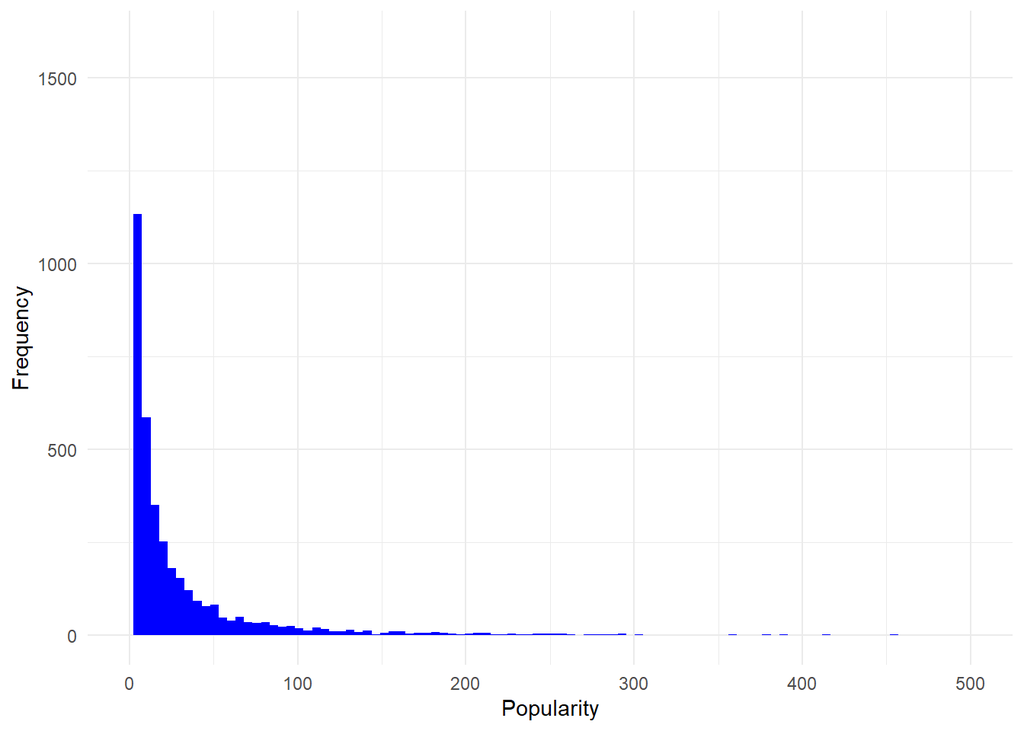

```r
# create 'popularity' feature
df_4 = df_4 %>% mutate(popularity = shares + comments + reaction_count)

# popularity distribution
df_4 %>%
  ggplot(aes(x=popularity)) +
  geom_histogram(fill = "blue",show.legend = F,bins = 100) +
  labs(x = "Popularity", y = "Frequency") +
  xlim(c(0,500)) +
  theme_minimal()
```

```r
# see the summary of all variables
summary(df_4)
```

```
##    post_id               time                      image_group
##  Length:5258        Min.   :2019-01-12 20:06:00   Min.   :0.0000
##  Class :character   1st Qu.:2019-12-14 18:24:00   1st Qu.:0.0000
##  Mode  :character   Median :2020-09-09 14:50:00   Median :0.0000
##                     Mean   :2020-07-12 13:33:48   Mean   :0.0445
##                     3rd Qu.:2021-02-27 22:46:58   3rd Qu.:0.0000
##                     Max.   :2021-07-23 17:06:48   Max.   :1.0000
##     comments           shares          text_char          year
##  Min.   :  0.000   Min.   : 0.0000   Min.   :  16.0   Length:5258
##  1st Qu.:  0.000   1st Qu.: 0.0000   1st Qu.:  76.0   Class :character
##  Median :  2.000   Median : 0.0000   Median : 115.0   Mode  :character
##  Mean   :  8.315   Mean   : 0.0369   Mean   : 173.8
##  3rd Qu.:  7.000   3rd Qu.: 0.0000   3rd Qu.: 185.0
##  Max.   :284.000   Max.   :22.0000   Max.   :7707.0
##     month               day                hour                like
##  Length:5258        Length:5258        Length:5258        Min.   :  0.00
##  Class :character   Class :character   Class :character   1st Qu.:  0.00
##  Mode  :character   Mode  :character   Mode  :character   Median :  1.00
##                                                           Mean   : 10.14
##                                                           3rd Qu.:  7.00
##                                                           Max.   :783.00
##       love              haha              wow               care
##  Min.   :  0.000   Min.   :  0.000   Min.   : 0.0000   Min.   : 0.0000
##  1st Qu.:  0.000   1st Qu.:  0.000   1st Qu.: 0.0000   1st Qu.: 0.0000
##  Median :  0.000   Median :  0.000   Median : 0.0000   Median : 0.0000
##  Mean   :  1.225   Mean   :  2.965   Mean   : 0.3577   Mean   : 0.4431
##  3rd Qu.:  0.000   3rd Qu.:  1.000   3rd Qu.: 0.0000   3rd Qu.: 0.0000
##  Max.   :229.000   Max.   :323.000   Max.   :94.0000   Max.   :97.0000
##       sad               angry           emoji_count         text2
##  Min.   :  0.0000   Min.   :  0.0000   Min.   :  0.000   Length:5258
##  1st Qu.:  0.0000   1st Qu.:  0.0000   1st Qu.:  0.000   Class :character
##  Median :  0.0000   Median :  0.0000   Median :  0.000   Mode  :character
##  Mean   :  0.8475   Mean   :  0.5295   Mean   :  1.062
##  3rd Qu.:  0.0000   3rd Qu.:  0.0000   3rd Qu.:  1.000
##  Max.   :185.0000   Max.   :223.0000   Max.   :117.000
##  reaction_count      doc_id            popularity
##  Min.   :   0.0   Length:5258        Min.   :   0.00
##  1st Qu.:   0.0   Class :character   1st Qu.:   2.00
##  Median :   3.0   Mode  :character   Median :   7.00
##  Mean   :  16.5                      Mean   :  24.86
##  3rd Qu.:  13.0                      3rd Qu.:  23.00
##  Max.   :1205.0                      Max.   :1318.00
```

## 4.2 Correlation

- Let’s first check correlation in our data.

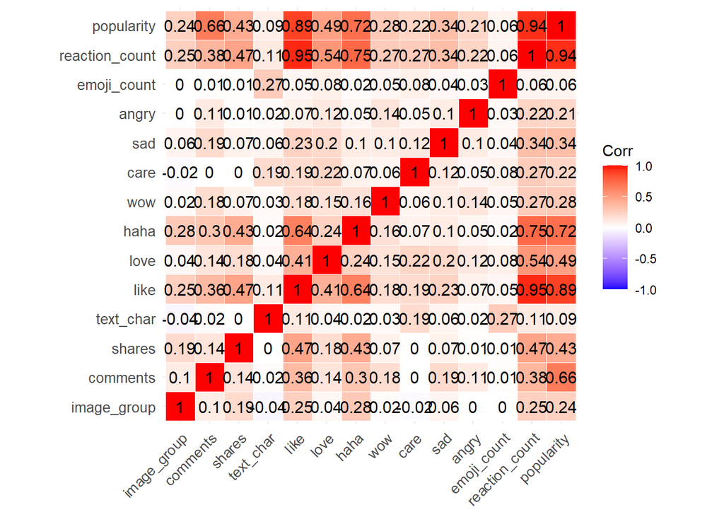

```r
# numeric
df_numeric = df_4 %>% select(-doc_id) %>% select_if(is.numeric)
corr = rcorr(as.matrix(df_numeric))
ggcorrplot::ggcorrplot(corr$r, outline.col = "white", lab = T, tl.cex = 10)
```

- Overall, popularity is highly and positively related to the number of likes, haha, comments, and shares, respectively.
- However, among different types of reactions, they are also related to each other, which might impact on prediction using a supervised machine learning such as a regression model or a decision tree.

## 4.3 Categorical

- Let’s inspect non-numerical attributes.
- We will start with date.

```r
# date range
range(df_4$time)
```

```
## [1] "2019-01-12 20:06:00 UTC" "2021-07-23 17:06:48 UTC"
```

```r
# covert class timedate to date
df_4 = df_4 %>% mutate(time2 = as.Date(time, format = "%Y-%m-%d"))
```

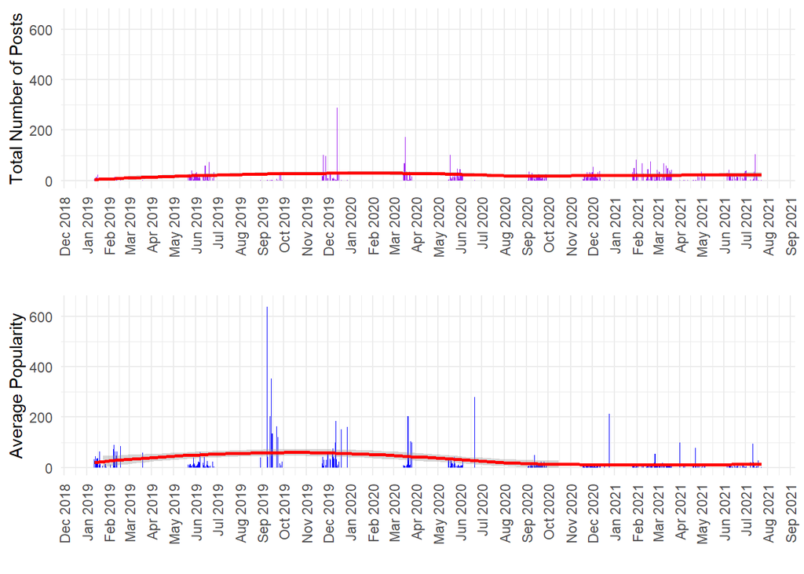

```r
# average popularity by date
options(repr.plot.height=6)
df_4 %>%
  group_by(time2) %>%
  summarise(total_pop = median(popularity)) %>%
  ggplot(aes(x=time2, y=total_pop)) +
  geom_col(fill='blue') +
  scale_y_continuous(labels=comma) +
  geom_smooth(col='red') +
  labs(x="", y="Average Popularity") +
  scale_x_date(date_breaks = "1 month", date_labels = "%b %Y") +
  theme_minimal() +
  theme(axis.text.x = element_text(angle = 90, vjust = 0.5, hjust=1)) +
  ylim(0,650) -> pop_date
# total posts by date
options(repr.plot.height=6)
df_4 %>%
  group_by(time2) %>%
  summarise(total_post = n()) %>%
  ggplot(aes(x=time2, y=total_post)) +
  geom_col(fill='purple') +
  scale_y_continuous(labels=comma) +
  geom_smooth(col='red') +
  labs(x="", y="Total Number of Posts") +
  scale_x_date(date_breaks = "1 month", date_labels = "%b %Y") +
  theme_minimal() +
  theme(axis.text.x = element_text(angle = 90, vjust = 0.5, hjust=1)) +
  ylim(0,650) -> post_date
grid.arrange(post_date,pop_date)
```

- For the plot above, the number of posts is not positively related to the average popularity.
- Let’s explore more on other elements of date.

```r
# create a new variable called weekday e.g., Tue
df_4$weekday <- lubridate::wday(df_4$time2, label=TRUE)

cat_var = c("year","month","day","weekday","hour")

# create a new function for date visualization
plotnight <- function(dataframe, cat_var, topN=10) {
    var_col <- enquo(cat_var) # envi variable

    dataframe %>% group_by(!!var_col) %>%
      summarize(median_pop = median(popularity)) %>%
      filter(median_pop>0) %>% top_n(topN, wt=median_pop) %>%
      ungroup() %>%
    ggplot(aes_(x=var_col, y=~median_pop, fill=var_col)) +
    geom_bar(stat='identity',show.legend = F)+
    scale_y_continuous(labels=comma)+
    labs(x="", y="Average Popularity") +
    theme(legend.position="none") +
    theme_minimal()
}
```

- Date visualization

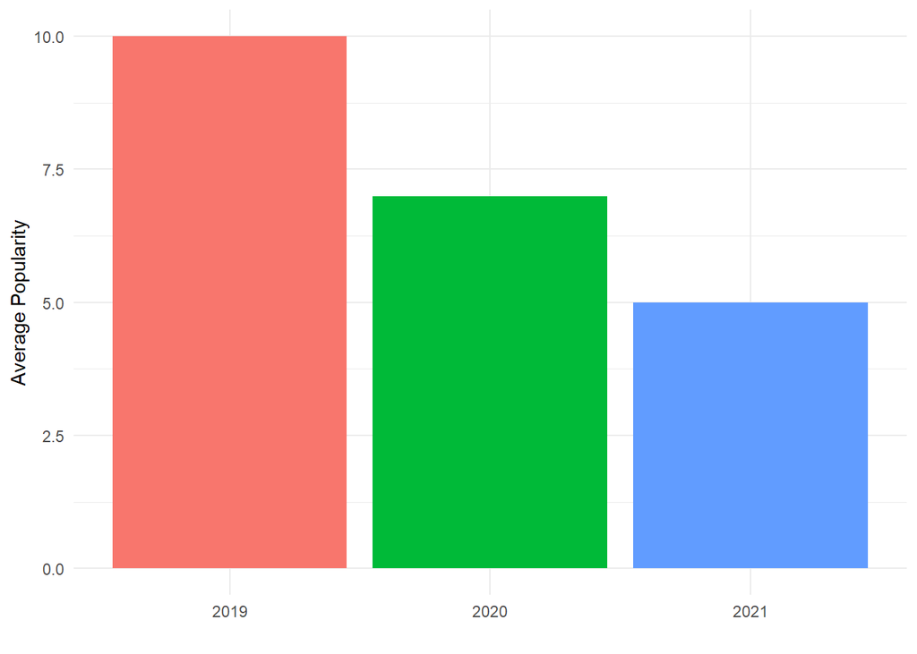

```r
# year
options(repr.plot.height=4)
plotnight(df_4, year)
```

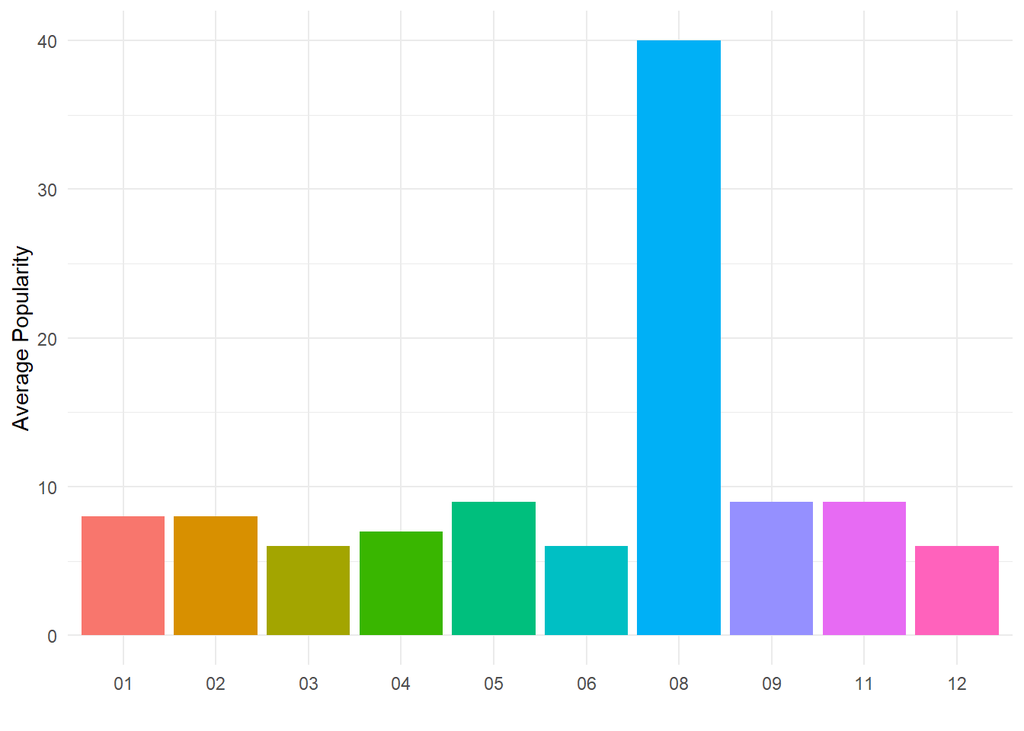

```r
# month
options(repr.plot.height=4)
plotnight(df_4, month) # August is an outlier
```

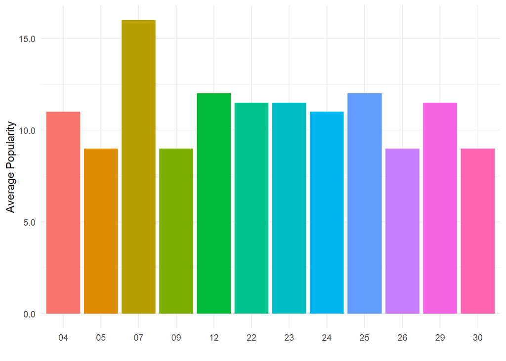

```r
# day
options(repr.plot.height=4)
plotnight(df_4, day)
```

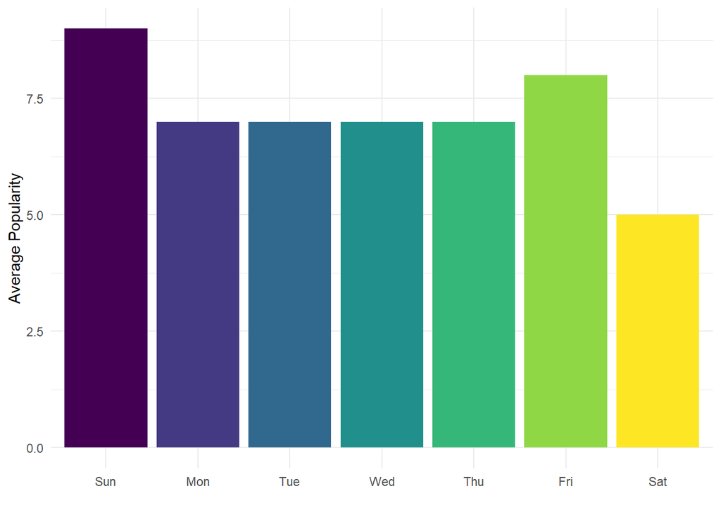

```r
# weekday
options(repr.plot.height=4)
plotnight(df_4, weekday)
```

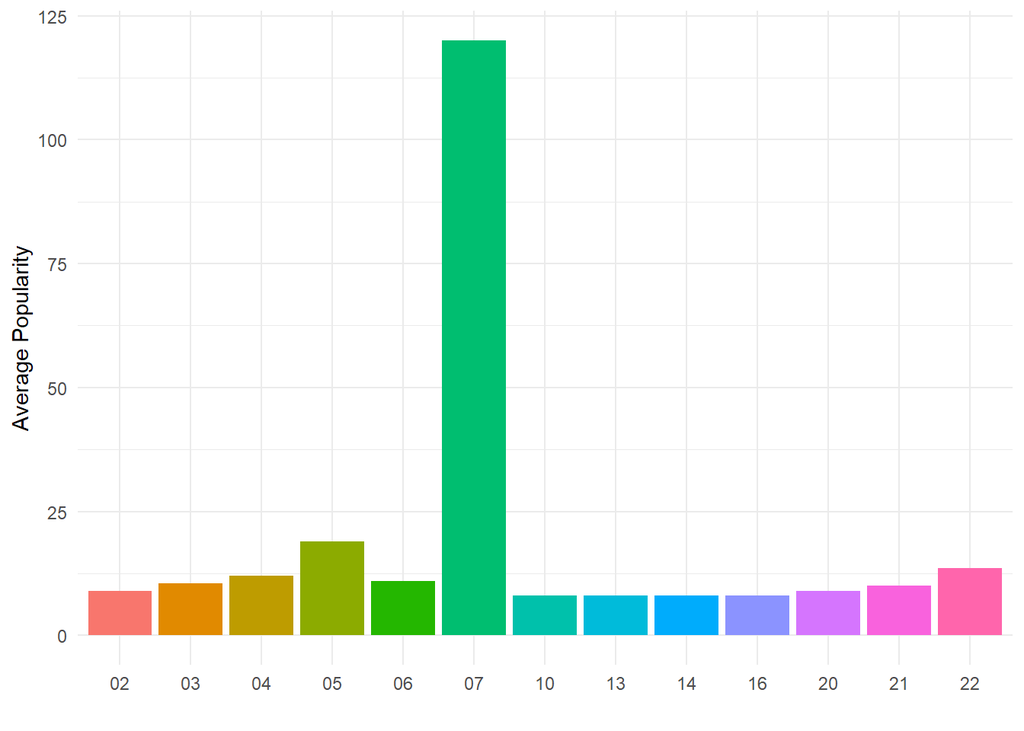

```r
# hour
options(repr.plot.height=4)
plotnight(df_4, hour) # 7.00 AM is an outlier
```

## 4.4 Image

- Let’s see if posts with image have higher popularity.

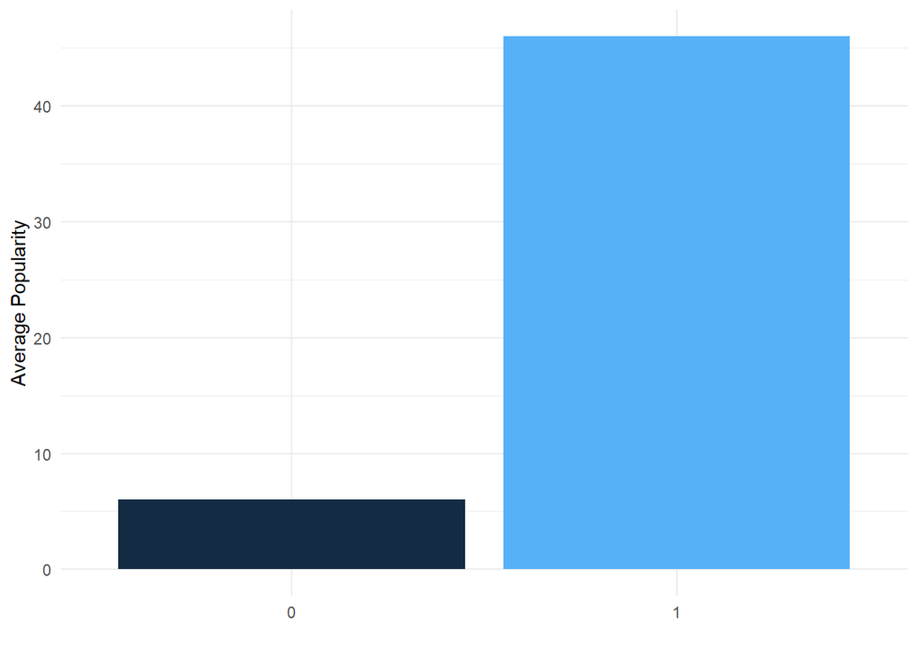

```r
# image
df_4 %>%
  group_by(image_group) %>%
  summarize(median_rn = median(popularity)) %>%
  filter(median_rn>0) %>%
  ungroup() %>%
  ggplot(aes(x=as.factor(image_group), y=median_rn, fill=image_group)) +
  geom_bar(stat='identity',show.legend = F)+scale_y_continuous(labels=comma)+
  labs(x="", y="Average Popularity")+
  theme(legend.position="none") +
  theme_minimal()
```

```r
df_4$image_group = as.factor(df_4$image_group)
```

- Posting with image has higher popularity.

## 4.5 Multicollinearity

- Previously, we have seen that like and haha are highly correlated.
- Let’s create a new feature to improve our incoming predictive model.

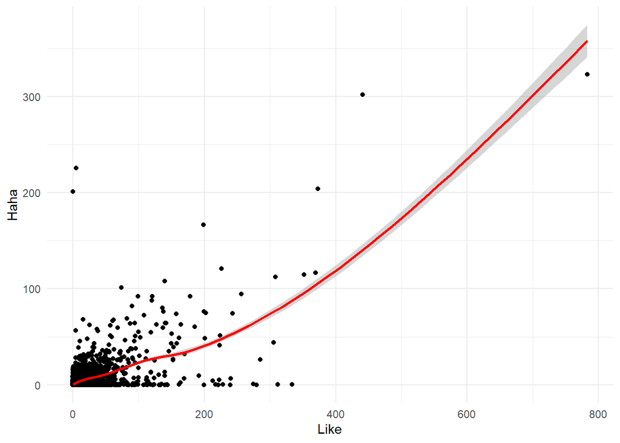

```r
# like vs haha
df_4 %>%
  ggplot(aes(x = like, y = haha)) +
  geom_jitter() +
  geom_smooth(col = "red") +
  labs(x = "Like",y="Haha") +
  theme_minimal()
```

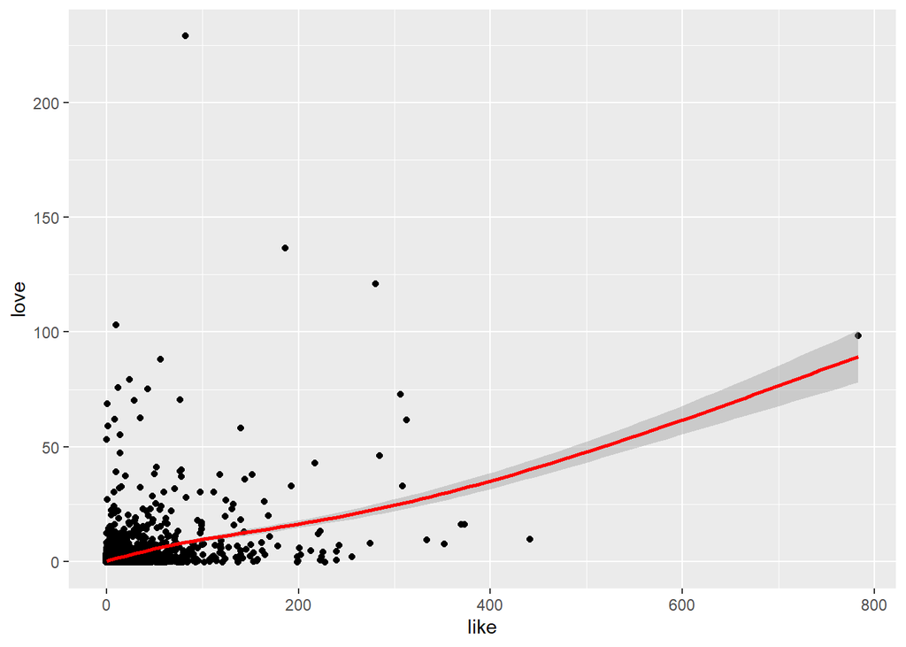

```r
# like vs love
df_4 %>% ggplot(aes(x = like, y = love)) + geom_jitter() + geom_smooth(col = "red")
```

```r
# new feature
df_4 = df_4 %>% mutate(like_haha = like / haha)

which(colSums(is.na(df_4)) > 0)
```

```
## like_haha
##        25
```

```r
df_4[is.na(df_4)] <- 0
df_4$like_haha[is.infinite(df_4$like_haha)] <- 0
```

- Let’s see the relationship between popularity and each reaction type.

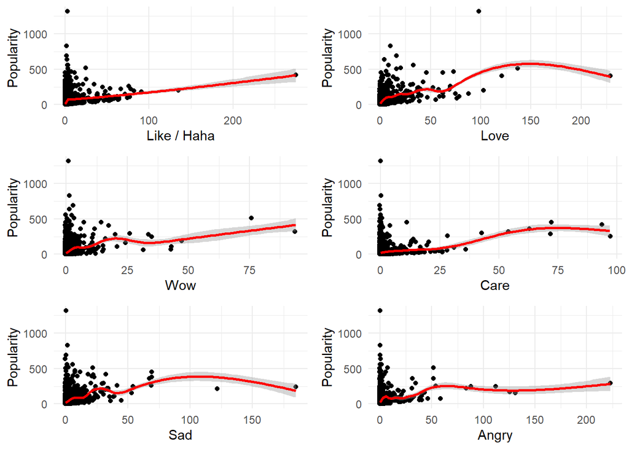

```r
# plot
df_4 %>%
  ggplot(aes(y = popularity, x = like_haha)) +
  geom_jitter() +
  geom_smooth(col = "red") +
  labs(x = "Like / Haha", y = "Popularity") +
  theme_minimal() -> re_1

df_4 %>%
  ggplot(aes(y = popularity, x = love)) +
  geom_jitter() +
  geom_smooth(col = "red") +
  labs(x = "Love", y = "Popularity") +
  theme_minimal() -> re_2

df_4 %>%
  ggplot(aes(y = popularity, x = wow)) +
  geom_jitter() +
  geom_smooth(col = "red") +
  labs(x = "Wow", y = "Popularity") +
  theme_minimal() -> re_3

df_4 %>%
  ggplot(aes(y = popularity, x = care)) +
  geom_jitter() +
  geom_smooth(col = "red") +
  labs(x = "Care", y = "Popularity") +
  theme_minimal() -> re_4

df_4 %>%
  ggplot(aes(y = popularity, x = sad)) +
  geom_jitter() +
  geom_smooth(col = "red") +
  labs(x = "Sad", y = "Popularity") +
  theme_minimal() -> re_5

df_4 %>%
  ggplot(aes(y = popularity, x = angry)) +
  geom_jitter() +
  geom_smooth(col = "red") +
  labs(x = "Angry", y = "Popularity") +
  theme_minimal() -> re_6

grid.arrange(re_1,re_2,re_3,re_4,re_5,re_6, ncol = 2)
```

- Let’s check correlation again to confirm we solve multicollinearity.

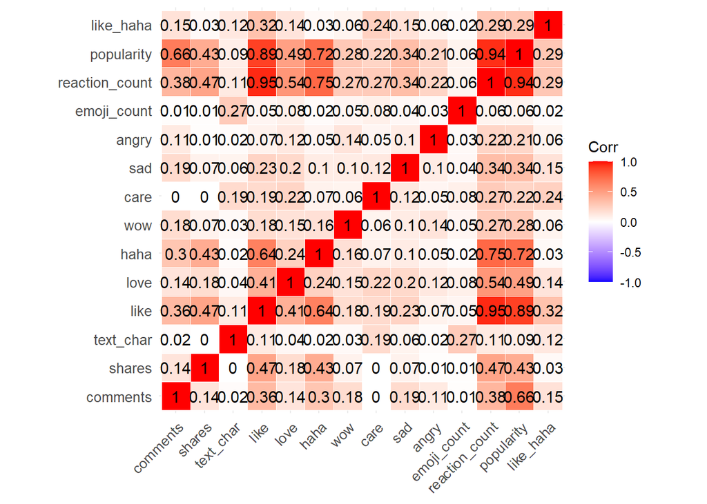

```r
# numeric
df_numeric = df_4 %>% select(-doc_id) %>% select_if(is.numeric)
corr = rcorr(as.matrix(df_numeric))
ggcorrplot::ggcorrplot(corr$r, outline.col = "white", lab = T, tl.cex = 10)
```

- Let’s transform variables to use in our upcoming model.

```r
# numeric
df_5 = df_4 %>%
  select(-c(post_id,time,time2,like,haha)) %>%
  mutate(weekday = factor(as.character(weekday), levels = c("Sun","Mon","Tue","Wed","Thu","Fri","Sat")),
         year = as.integer(year),
         month = as.integer(month),
         day = as.integer(day),
         hour = as.integer(hour))
```

## 4.6 Comments and Shares

- Let’s explore the relationship between popularity and comments/shares.

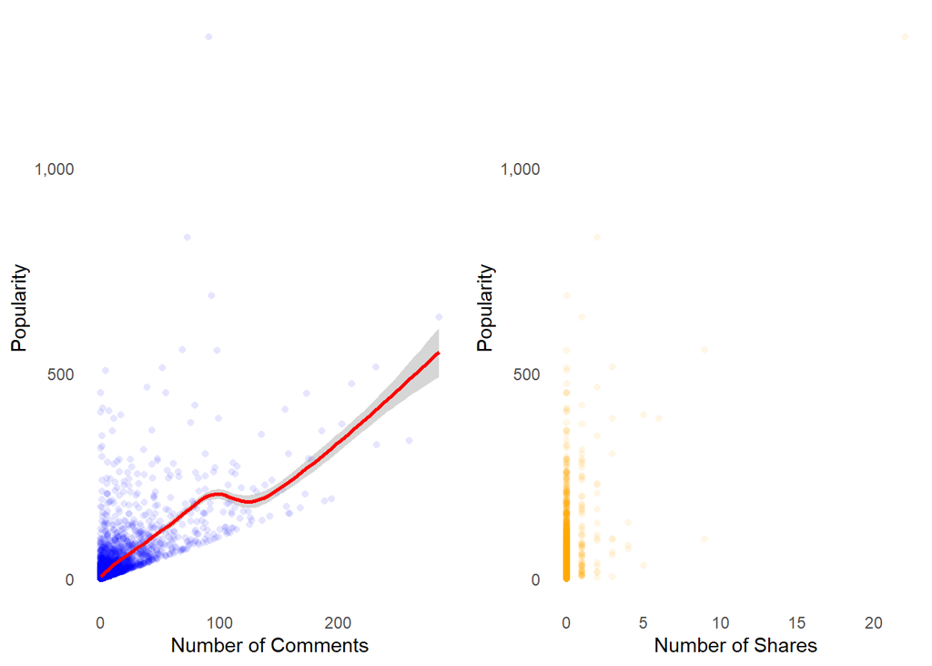

```r
# to see the relationship of popularity by comments
df_5 %>%
    ggplot(aes(x=comments, y= popularity)) +
      geom_point(alpha = 0.1, shape = 16, color = "blue") +
      geom_smooth(col = "red") +
      scale_y_continuous(labels=comma) +
      labs(x="Number of Comments", y="Popularity") +
      theme_minimal() +
      theme(panel.grid.major = element_blank(), panel.grid.minor = element_blank()) -> a

# to see the relationship of popularity by shares
df_5 %>%
    ggplot(aes(x=shares, y= popularity)) +
      geom_point(alpha = 0.1, shape = 16, color = "orange") +
      geom_smooth(col = "red",method = "loess") +
      scale_y_continuous(labels=comma) +
      labs(x="Number of Shares", y="Popularity") +
      theme_minimal() +
      theme(panel.grid.major = element_blank(), panel.grid.minor = element_blank()) -> b

grid.arrange(a,b, ncol = 2)
```

# 5 NLP

- In this section, we will find the most frequent word (unigram) or words (bigram) used across the posts to gain an idea what posts are about.

## 5.1 Lemmatization

- Let’s do lemmatization and POS-taggaing by loading the model using UDpipe library.

```r
langmodel_download <- udpipe::udpipe_download_model("english")
langmodel <- udpipe::udpipe_load_model(langmodel_download$file_model)
```

- Let’s do annotation.

```r
postagged <- udpipe_annotate(langmodel,
                             df_5$text2,
                             parallel.cores = 10,
                             trace = 1000)
```

- We can create a data frame and explore it.

```r
# create a data frame of pos-tagged texts
postagged <- as.data.frame(postagged)
head(postagged)

# save the working file as .rds
saveRDS(postagged,file = "postagged.rds")
```

- Let’s filter and detokenize the postagged terms.

```r
# read data
postagged = readRDS("postagged.rds")

# filter only nouns, adj, and adv
lematized <- postagged %>% filter(upos %in% c("NOUN",
                                              "ADJ",
                                              "ADV")) %>% select(doc_id,lemma) %>% group_by(doc_id) %>% summarise(documents_pos_tagged = paste(lemma,collapse = " "))

# combine tables
df_6 <- df_5 %>% left_join(lematized) %>% select(-text2)
# save the working file as .rds
saveRDS(df_6,file = "df_6.rds")

# check NA values across columns
which(colSums(is.na(df_6)) > 0)
```

```
## documents_pos_tagged
##                   20
```

```r
# drop NULL values
df_6 = df_6 %>% drop_na()

# remove postag
remove(postagged)
```

## 5.2 Unigram

- We have removed unnecessary words or words with similar roots e.g., interest vs interested, including selecting only nouns, adjectives, and adverbs since it’s more meaningful and could be used for sentiment analysis.
- We will now tokenize a sentence into a single word (unigram),

### 5.2.1 Tokenization

- Let’s do word tokenization using unigram and tidy text approach
- More information here: https://www.tidytextmining.com/tidytext.html

```r
# word tokenization
token_df_all <- df_6 %>% unnest_tokens(word,documents_pos_tagged)

# check the language and remove non-English words
token_df_all$lan <- cld3::detect_language(token_df_all$word)
token_df_all <- token_df_all %>% filter(lan=="en")
```

- We next back up the file.

```r
saveRDS(token_df_all,file = "token_df_all.rds")
```

- Let’s inspect text length.

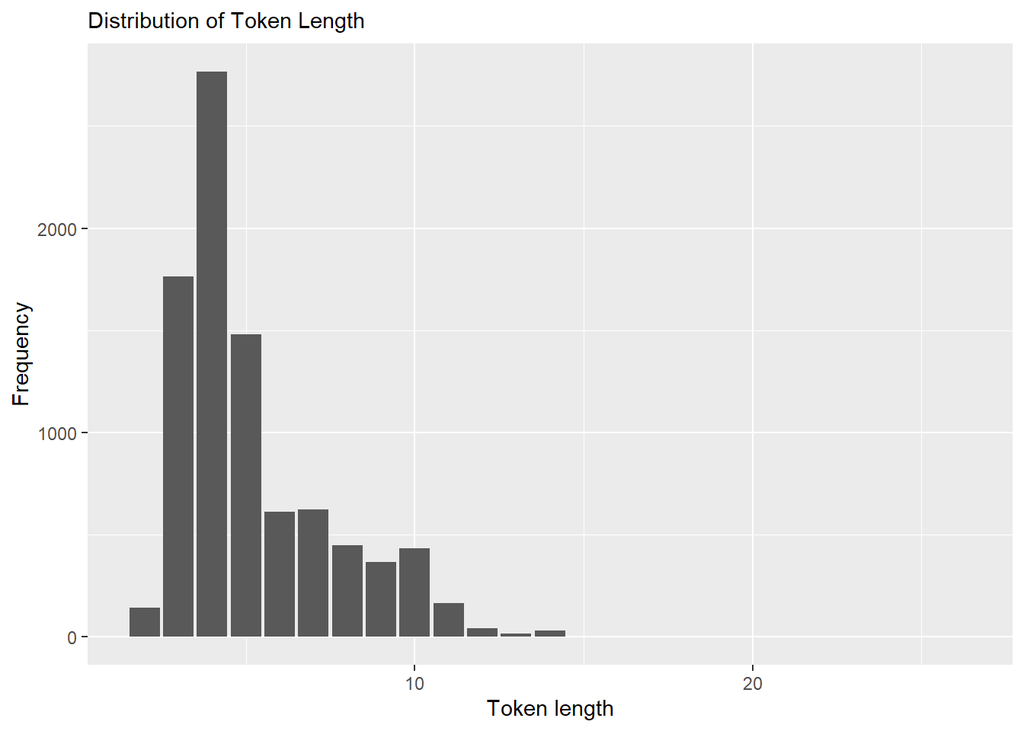

```r
# read data
token_df_all = readRDS("token_df_all.rds")

# calculate the token length
token_df_all$token_length <- nchar(token_df_all$word)

# let's have a look on the distribution
token_df_all %>% group_by(token_length) %>% summarise(total =n()) %>% ggplot(aes(x=token_length, y=total)) + geom_col() + labs(x="Token length", y="Frequency", subtitle="Distribution of Token Length")
```

```r
# let's have a look at the distribution of tokens again
token_df_all %>% group_by(token_length) %>%
  summarise(total =n()) %>%
  arrange(desc(token_length))
```

```
## # A tibble: 19 x 2
##    token_length total
##           <int> <int>
##  1           26     1
##  2           24     1
##  3           18     1
##  4           17     2
##  5           16     3
##  6           15     3
##  7           14    30
##  8           13    15
##  9           12    43
## 10           11   166
## 11           10   435
## 12            9   367
## 13            8   449
## 14            7   625
## 15            6   613
## 16            5  1481
## 17            4  2767
## 18            3  1765
## 19            2   142
```

- We can see that the word length is slightly right skewed where the median is approximately 3-5 characters. – We will remove outliers using IQR approach following [@Hubert].

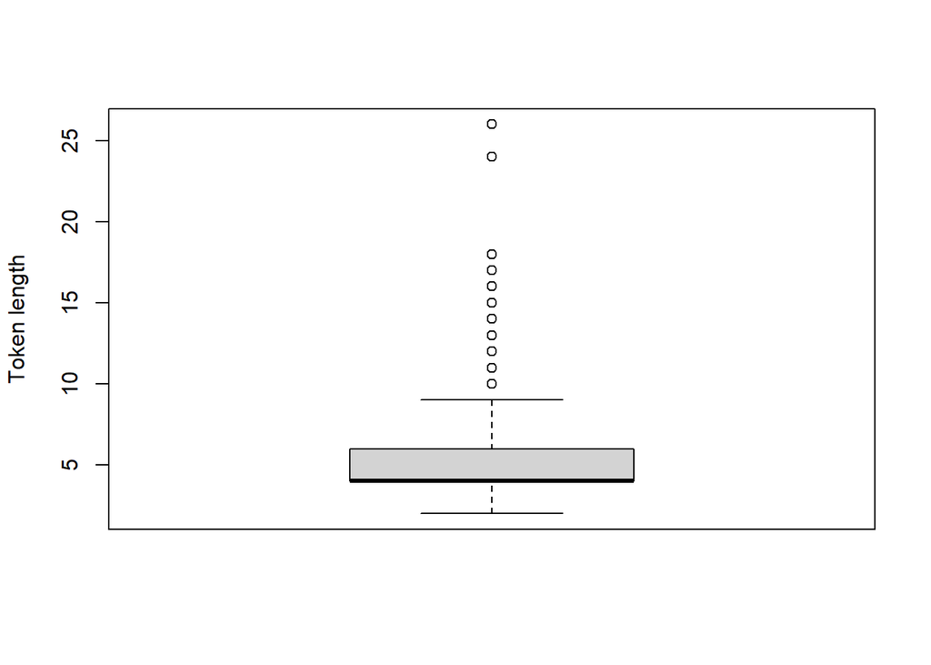

```r
outliers1 <- boxplot(token_df_all$token_length, ylab = "Token length")$out
```

```r
# drop the rows containing outliers
token_df_all <- token_df_all[!token_df_all$token_length %in% outliers1,]
```

```r
# inspect top frequent words
token_df_all %>% count(word, sort=T)

# remove null values in words
token_df_all = token_df_all[!is.na(token_df_all$word),]
```

- Let’s remove stop words using a package stopwords [@Benoit].

```r
# load stop words
data("stop_words")
token_df2 = token_df_all %>% anti_join(stop_words, by = "word")

token_df2 %>% count(word, sort=T)
```

- Let’s add custom stop words.

```r
# generate new stop words
mystopwords <- tibble(word =c("day","time"))

# combine data sets
token_df2 = token_df2 %>% anti_join(mystopwords, by = "word")

# explore top words across corpus
token_df2 %>% group_by(word) %>%
  summarise(total =n()) %>%
  arrange(desc(total)) %>%
  top_n(10)
```

```
## # A tibble: 10 x 2
##    word    total
##    <chr>   <int>
##  1 lecture    87
##  2 library    72
##  3 party      61
##  4 issue      56
##  5 game       49
##  6 country    46
##  7 lonely     40
##  8 page       40
##  9 sexual     39
## 10 french     37
```

- As a result, top frequent words generate a sense of studying and partying.

```r
# save file
saveRDS(token_df2,file = "token_df2.rds")
```

### 5.2.2 TF-IDF

#### 5.2.2.1 Document level

- To gain an insight of how important of words is, we use TF-IDF metric to measure word importance in our documents (corpus). – Let’s calculate TF-IDF using tidy data principles. [https://www.tidytextmining.com/tfidf.html]

```r
listing_words = token_df2 %>% count(doc_id, word, sort=T)

total_words <- listing_words %>%
  group_by(doc_id) %>%
  summarize(total = sum(n))

listing_words <- listing_words %>%
  left_join(total_words)
listing_tf_idf <- listing_words %>% bind_tf_idf(word,doc_id,n) %>% select(-total)
```

- Next, we will inspect the data with TF-IDF score.

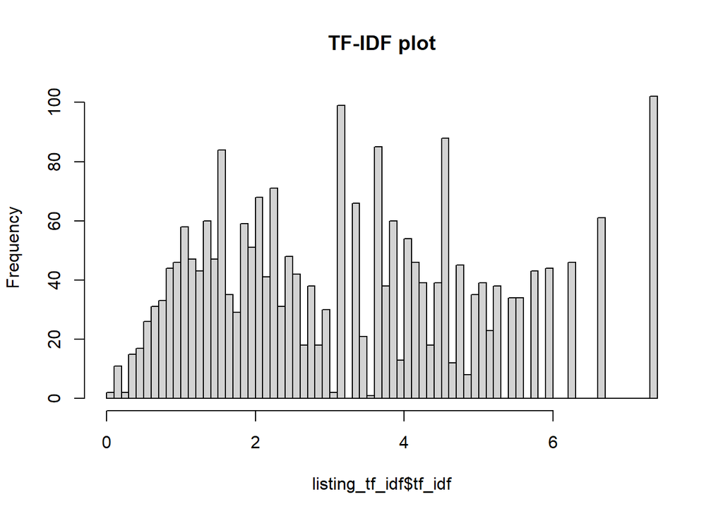

```r
# plot a histogram
hist(listing_tf_idf$tf_idf,breaks = 80,main="TF-IDF plot")
```

- Let’s zoom in the data where TF-IDF < 6

```r
listing_tf_idf <- listing_tf_idf %>% filter(tf_idf<=6)
```

```r
listing_tf_idf_2 <- listing_tf_idf %>% filter(tf_idf<=5.7 & tf_idf >= 0.78)

# statistical summary
summary(listing_tf_idf_2$tf_idf)
```

```
##    Min. 1st Qu.  Median    Mean 3rd Qu.    Max.
##  0.7825  1.7438  2.8747  2.9604  4.1007  5.5671
```

```r
# let's explore the top 10 words with the highest tf-idf
listing_tf_idf_2 %>%
  group_by(word) %>%
  arrange(desc(tf_idf)) %>%
  top_n(10)
```

```
## # A tibble: 1,532 x 6
## # Groups:   word [353]
##    doc_id  word          n    tf   idf tf_idf
##    <chr>   <chr>     <int> <dbl> <dbl>  <dbl>
##  1 doc1060 candidate     2     1  5.57   5.57
##  2 doc4520 lunch         2     1  5.57   5.57
##  3 doc1085 faster        1     1  5.57   5.57
##  4 doc1198 placement     1     1  5.57   5.57
##  5 doc1290 poster        1     1  5.57   5.57
##  6 doc1372 candidate     1     1  5.57   5.57
##  7 doc1457 placement     1     1  5.57   5.57
##  8 doc1458 means         1     1  5.57   5.57
##  9 doc1554 climate       1     1  5.57   5.57
## 10 doc1696 climate       1     1  5.57   5.57
## # ... with 1,522 more rows
```

- From the top highest tf-idf words, they are mostly nouns, which is relatively difficult to understand the context compared with adjectives and adverbs.

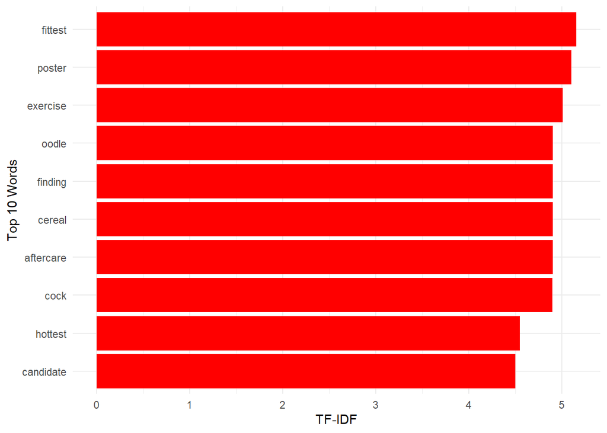

```r
listing_tf_idf_2 %>%
  group_by(word) %>%
  summarize(tf_idf = mean(tf_idf)) %>%
  #arrange(desc(tf_idf)) %>%
  #top_n(10) %>%
  slice_max(tf_idf, n = 10) %>%
  ggplot(aes(y=tf_idf, x=reorder(word, tf_idf))) +
  geom_col(show.legend = FALSE, fill = "Red") +
  theme_minimal() +
  labs(y = "TF-IDF", x = "Top 10 Words") +
  coord_flip()
```

## 5.3 Bi-grams

### 5.3.1 Tokenization

- Let’s tokenize data using bigrams and remove stop words.

```r
token_df_bi <- df_6 %>%
  unnest_tokens(bigram, documents_pos_tagged, token="ngrams",n=2) %>%
  separate(bigram, c("word1","word2"), sep = " ") %>%
  filter(!word1 %in% stop_words$word) %>%
  filter(!word1 %in% mystopwords$word) %>%
  filter(!word2 %in% stop_words$word) %>%
  filter(!word2 %in% mystopwords$word) %>%
  unite(bigram, word1, word2, sep = " ")

# check the language again and remove non-English words
token_df_bi$lan <- cld3::detect_language(token_df_bi$bigram)
token_df_bi <- token_df_bi %>% filter(lan=="en")

# remove unused features
token_df_bi %>% select(-lan) -> token_df_bi

# save file
saveRDS(token_df_bi,file = "token_df_bi.rds")
```

- Explore the most common bi-grams (two words) at a corpus level.

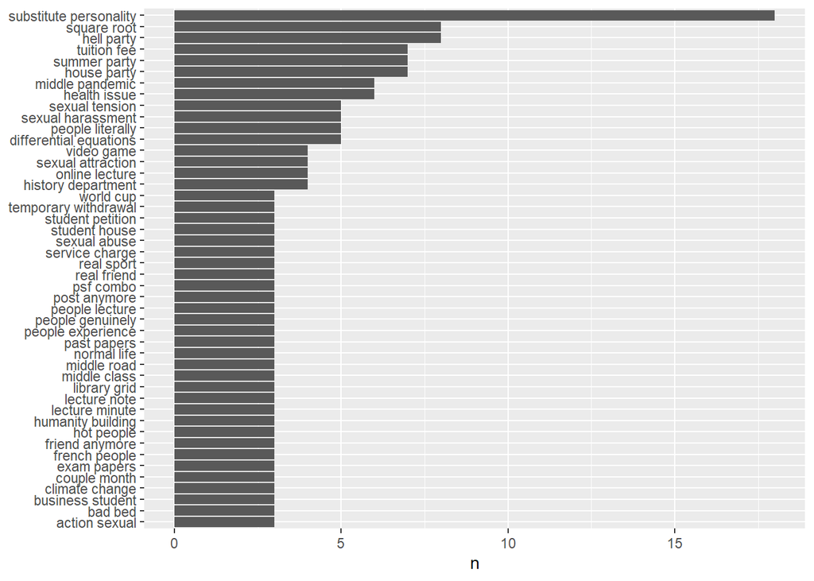

```r
# top 20 words
token_df_bi %>%
  count(bigram) %>%
  mutate(bigram=reorder(bigram,n)) %>%
  slice_max(n,n=20) %>%
  ggplot(aes(bigram,n)) +
  geom_bar(stat = "identity") +
  xlab(NULL) +
  coord_flip()
```

### 5.3.2 TF-IDF

#### 5.3.2.1 Document level

```r
# calculating TF-IDF scores
bi_words = token_df_bi %>% count(doc_id, bigram, sort=T)

total_words <- bi_words %>%
  group_by(doc_id) %>%
  dplyr::summarize(total = sum(n))

# joining data
bi_words <- bi_words %>%
  left_join(total_words)
bi_tf_idf <- bi_words %>% bind_tf_idf(bigram,doc_id,n) %>% select(-total)
```

```r
# let's explore the top 10 words with the lowest tf-idf
bi_tf_idf %>%
  group_by(bigram) %>%
  arrange(desc(tf_idf)) %>%
  top_n(10)
```

```
## # A tibble: 2,951 x 6
## # Groups:   bigram [2,746]
##    doc_id  bigram               n    tf   idf tf_idf
##    <chr>   <chr>            <int> <dbl> <dbl>  <dbl>
##  1 doc969  related math         2     1  7.32   7.32
##  2 doc1002 library don          1     1  7.32   7.32
##  3 doc1020 length middle        1     1  7.32   7.32
##  4 doc1023 phone red            1     1  7.32   7.32
##  5 doc1042 victory royale       1     1  7.32   7.32
##  6 doc1043 vote strictly        1     1  7.32   7.32
##  7 doc1050 doctor note          1     1  7.32   7.32
##  8 doc1054 ds battery           1     1  7.32   7.32
##  9 doc1064 normal evision       1     1  7.32   7.32
## 10 doc1069 access wellbeing     1     1  7.32   7.32
## # ... with 2,941 more rows
```

– All words are nouns with low level of insights. – Therefore, we need to remove common and rare words i.e., outliers.

```r
# check statistical summary
summary(bi_tf_idf$tf_idf)
```

```
##    Min. 1st Qu.  Median    Mean 3rd Qu.    Max.
##  0.1525  1.5368  3.3124  3.6559  7.3179  7.3179
```

```r
# drop the rows containing outliers
bi_tf_idf_2 <- bi_tf_idf %>% filter(tf_idf <= 5.5 & tf_idf >= 0.98)

bi_tf_idf_2 %>%
    group_by(bigram) %>%
    arrange(desc(tf_idf)) %>%
    top_n(10)
```

```
## # A tibble: 1,697 x 6
## # Groups:   bigram [1,615]
##    doc_id  bigram                     n    tf   idf tf_idf
##    <chr>   <chr>                  <int> <dbl> <dbl>  <dbl>
##  1 doc1392 tuition fee                1 1      5.37   5.37
##  2 doc4399 summer party               1 1      5.37   5.37
##  3 doc4484 house party                1 1      5.37   5.37
##  4 doc4673 summer party               1 1      5.37   5.37
##  5 doc306  vaccination clinic         2 0.667  7.32   4.88
##  6 doc594  foreign language           2 0.667  7.32   4.88
##  7 doc3128 substitute personality     1 1      4.43   4.43
##  8 doc3223 substitute personality     1 1      4.43   4.43
##  9 doc3396 substitute personality     1 1      4.43   4.43
## 10 doc3502 substitute personality     1 1      4.43   4.43
## # ... with 1,687 more rows
```

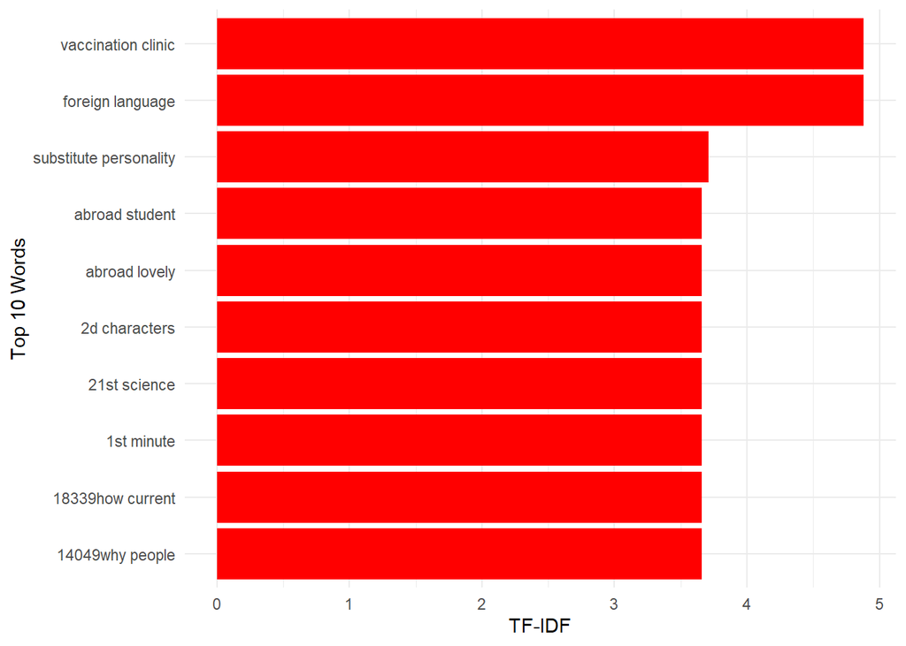

```r
bi_tf_idf_2 %>%
  group_by(bigram) %>%
  summarize(tf_idf = mean(tf_idf)) %>%
  slice_max(tf_idf, n = 10,with_ties = F)  %>%
  ggplot(aes(y=tf_idf, x=reorder(bigram, tf_idf))) +
  geom_col(show.legend = FALSE, fill = "Red") +
  theme_minimal() +
  labs(y = "TF-IDF", x = "Top 10 Words") +
  coord_flip()
```

- The context represents something related to the COVID-19 pandemic including students and language.

## 5.4 Formality

- Let’s retrieve formality of texts since it might relate to popularity i.e., more formaly of the post, more popular the post is.

```r
df_7 = df_6 %>% left_join(df_5 %>% select(doc_id,text2), by = "doc_id")

# extract formality
#options(java.parameters = "-Xmx4g")
formality <- qdap::formality(df_7$text2,df_7$doc_id)
formality$formality %>% select(doc_id,formality) -> formality_calc

# join data tables
df_7 %>% left_join(formality_calc, by = "doc_id") -> df_7

# back up the data and save into .rds file
saveRDS(df_7, file = "df_7.rds")

# check NA values across columns
which(colSums(is.na(df_7)) > 0)
```

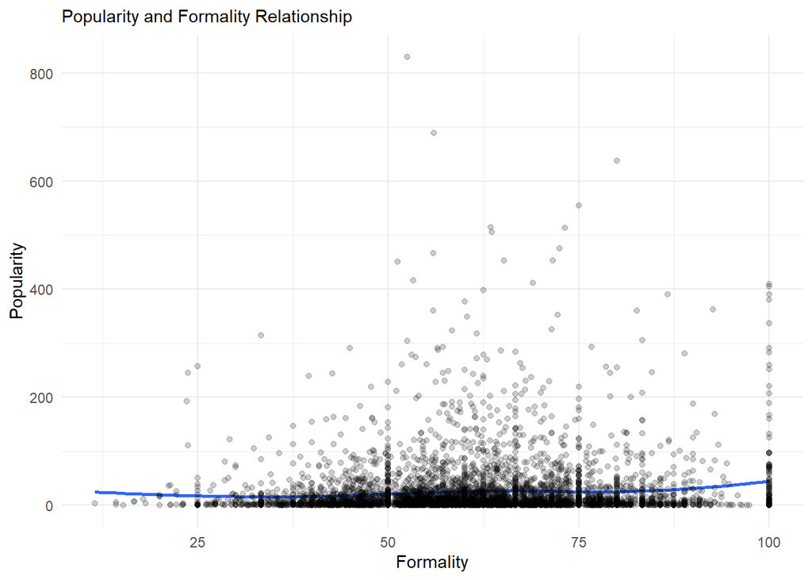

```r
df_7 = readRDS("df_7.rds")

# formality
df_7 %>%
  select(formality,popularity) %>%
  na.omit() %>%
  ggplot(aes(x=formality,y=popularity))+
  geom_smooth(method="loess",se = F)+
  geom_point(alpha=0.2) +
  labs(x="Formality", y="Popularity",
       subtitle="Popularity and Formality Relationship") +
  theme_minimal()
```

## 5.5 Readability

- After calculating the formality, we can also extract the readability (easiness).

```r
# create an empty data frame
readability_all <- data.frame()

# calculate readability score
for(i in 1:nrow(df_7)){

  readability_h <- data.frame()

  this_text <- iconv(df_7$text2[i])
  this_text <- cleanse_text(this_text)

  tryCatch(readability_h <- flesch_kincaid(this_text),error=function(e){
    cat("Error parsing")
  })

  if(!is.null(readability_h$Readability)){

    readability_h <- readability_h$Readability
    readability_h$doc_id <- df_7$doc_id[i]
    readability_all <- bind_rows(readability_all,readability_h)
  }

  print(i)
}
```

```r
# join data tables
df_8 <- df_7 %>%
  left_join(readability_all, by = "doc_id") %>% select(-c(all,word.count,sentence.count,syllable.count))

# back up the file
saveRDS(df_8, file = "df_8.rds")
```

- Now, let’s explore reading grade level.

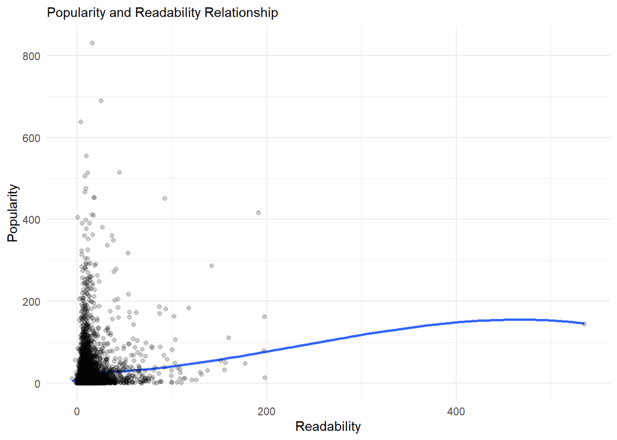

```r
# plot reading grade level against review rating scores
df_8 %>%
  select(FK_grd.lvl,popularity) %>%
  na.omit() %>%
  ggplot(aes(x=FK_grd.lvl,y=popularity))+
  geom_smooth(method="loess",se = F)+
  geom_point(alpha=0.2) +
  labs(x="Readability", y="Popularity",
       subtitle="Popularity and Readability Relationship") +
  theme_minimal()
```

## 5.6 Sentiment

- Let’s also extract polarity (positive sentiment - negative sentiment) including emotions e.g., anger, trust.

```r
batch_sentiment_by = function(reviews, batch_size = 200, ...) {
  review_batches = split(reviews, ceiling(seq_along(reviews)/batch_size))
  x = rbindlist(lapply(review_batches, sentiment_by, ...))
  x[, element_id := .I]
  x[]
}

sent_df = batch_sentiment_by(df_8$documents_pos_tagged) %>%
  mutate(doc_id2 = paste0("doc",row_number()))
```

```r
df_8 = df_8 %>%
  mutate(doc_id2 = paste0("doc",row_number()))

# joining data
df_9 = df_8 %>%
  left_join(sent_df) %>%
  select(-sd,-element_id)
```

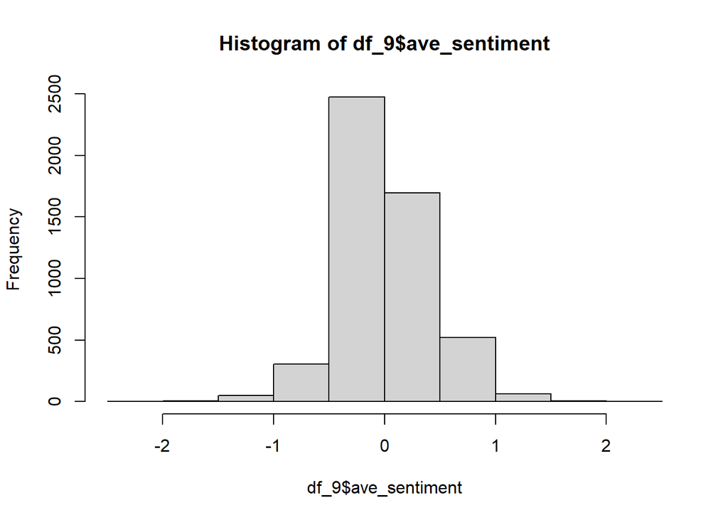

```r
hist(df_9$ave_sentiment)
```

```r
d <- get_nrc_sentiment(df_9$documents_pos_tagged)
df_10 = cbind(df_9,d)
df_10 = df_10 %>% select(-positive,-negative)
```

- Let’s visualize the emotions by date index.

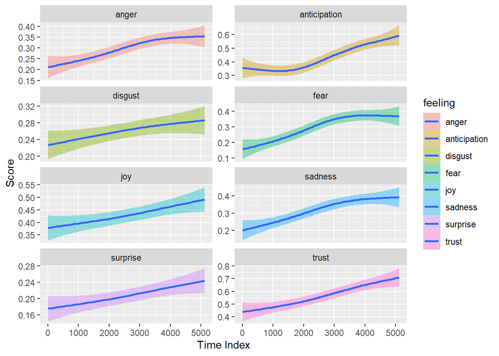

```r
df_10 %>%
  arrange(year,month,day) %>%
  mutate(time = row_number()) %>%
  pivot_longer(anger:trust,names_to = "feeling",values_to="polarity") %>%
  ggplot(aes(x=time,y=polarity,fill=feeling)) +
  geom_smooth() +
  facet_wrap(~feeling,scales="free_y",ncol=2) +
  labs(x = "Time Index", y = "Score")
```

- Increasing scores of each emotion facet is observed across the period.
- Let’s visualize the relationship between popularity and polarity.

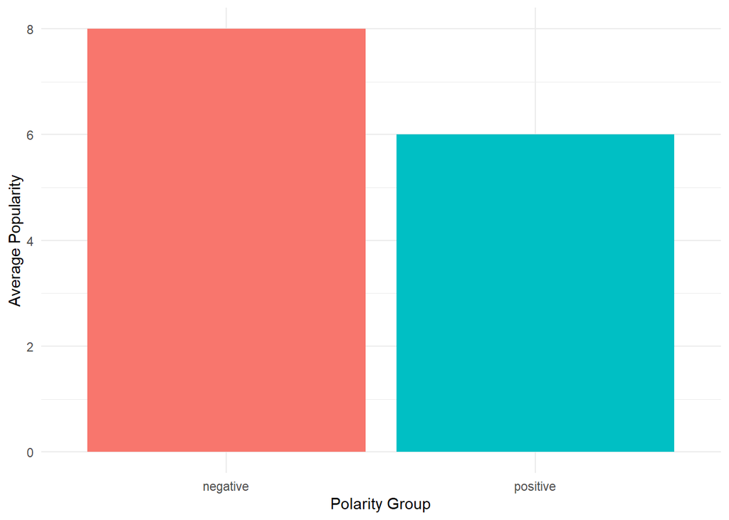

```r
# popularity vs sentiment
df_10 %>%
  mutate(senti_group = if_else(ave_sentiment >= 0, "positive","negative")) %>%
  group_by(senti_group) %>%
  summarize(mean_pop = median(popularity)) %>%
  ggplot(aes(y=mean_pop,x=senti_group)) +
  geom_col(aes(fill = senti_group), show.legend = F) +
  theme_minimal() +
  labs(x="Polarity Group", y = "Average Popularity")
```

- Interestingly, this is counterintuitive where posts with negative have higher average popularity.

# 6 Modelling: Regression

## 6.1 Pre-processing data

- Let’s partition the data by type of features.

```r
# non-numerical data set
df_etc = df_10 %>%
  select_if(negate(is.numeric)) %>%
  select(image_group,weekday)

# numerical data set
df_numeric = df_10 %>%
  select_if(is.numeric) %>%
  select(comments:text_char,love:emoji_count,like_haha,
         popularity,formality,FK_grd.lvl,ave_sentiment,
         anger:trust)

# time data set
df_time = df_10 %>% select(year:hour)
```

- Now, let’s do data normalization to use in a regression model.

```r
preproc2 <- preProcess(df_numeric, method=c("range"))
norm2 <- predict(preproc2, df_numeric)
```

- Let’s combine the data.

```r
df_reg = cbind(norm2, df_etc,df_time)
```

## 6.2 Regression

- Let’s run an initial regression model.

```r
model <- lm(popularity ~ ., data = df_reg)
summary(model)
```

```
##
## Call:
## lm(formula = popularity ~ ., data = df_reg)
##
## Residuals:
##      Min       1Q   Median       3Q      Max
## -0.24156 -0.00736 -0.00307  0.00146  0.73438
##
## Coefficients:
##                 Estimate Std. Error t value Pr(>|t|)
## (Intercept)   -9.924e-01  1.403e+00  -0.707   0.4794
## comments       4.995e-01  7.072e-03  70.633  < 2e-16 ***
## shares         2.620e-01  1.504e-02  17.422  < 2e-16 ***
## text_char     -7.608e-02  9.200e-02  -0.827   0.4083
## love           6.273e-01  1.724e-02  36.376  < 2e-16 ***
## wow            2.337e-01  1.772e-02  13.191  < 2e-16 ***
## care           2.020e-01  1.477e-02  13.673  < 2e-16 ***
## sad            3.153e-01  1.844e-02  17.094  < 2e-16 ***
## angry          2.395e-01  1.902e-02  12.597  < 2e-16 ***
## emoji_count    4.064e-03  1.528e-02   0.266   0.7902
## like_haha      2.723e-01  1.889e-02  14.417  < 2e-16 ***
## formality      1.452e-03  2.790e-03   0.520   0.6030
## FK_grd.lvl     9.485e-02  8.880e-02   1.068   0.2855
## ave_sentiment -2.615e-03  6.216e-03  -0.421   0.6740
## anger          2.459e-02  1.118e-02   2.200   0.0279 *
## anticipation   1.379e-02  1.124e-02   1.227   0.2199
## disgust       -2.567e-03  6.619e-03  -0.388   0.6981
## fear           1.136e-02  1.205e-02   0.943   0.3459
## joy           -3.810e-02  8.760e-03  -4.349 1.39e-05 ***
## sadness       -9.845e-04  1.233e-02  -0.080   0.9364
## surprise      -1.377e-02  7.111e-03  -1.936   0.0529 .
## trust          5.910e-02  1.381e-02   4.279 1.91e-05 ***
## image_group1   3.622e-02  2.359e-03  15.355  < 2e-16 ***
## weekdayMon    -3.615e-03  1.747e-03  -2.069   0.0386 *
## weekdayTue     8.692e-04  1.817e-03   0.478   0.6324
## weekdayWed     1.097e-04  1.892e-03   0.058   0.9538
## weekdayThu    -2.221e-03  1.747e-03  -1.272   0.2035
## weekdayFri    -2.126e-03  1.950e-03  -1.090   0.2758
## weekdaySat    -1.966e-03  1.807e-03  -1.088   0.2767
## year           4.926e-04  6.941e-04   0.710   0.4779
## month          3.268e-04  1.578e-04   2.071   0.0384 *
## day            2.776e-05  5.490e-05   0.506   0.6131
## hour          -1.488e-04  7.482e-05  -1.989   0.0467 *
## ---
## Signif. codes:  0 '***' 0.001 '**' 0.01 '*' 0.05 '.' 0.1 ' ' 1
##
## Residual standard error: 0.03231 on 5082 degrees of freedom
## Multiple R-squared:  0.7338, Adjusted R-squared:  0.7321
## F-statistic: 437.8 on 32 and 5082 DF,  p-value: < 2.2e-16
```

- Let’s use stepwise AIC algorithm to find the best predictors.

```r
# using stepwise AIC to find the best predictors
aic_model = MASS::stepAIC(model, direction = "both")
```

```
## Start:  AIC=-35078.87
## popularity ~ comments + shares + text_char + love + wow + care +
##     sad + angry + emoji_count + like_haha + formality + FK_grd.lvl +
##     ave_sentiment + anger + anticipation + disgust + fear + joy +
##     sadness + surprise + trust + image_group + weekday + year +
##     month + day + hour
##
##                 Df Sum of Sq     RSS    AIC
## - sadness        1    0.0000  5.3068 -35081
## - emoji_count    1    0.0001  5.3069 -35081
## - disgust        1    0.0002  5.3070 -35081
## - ave_sentiment  1    0.0002  5.3070 -35081
## - day            1    0.0003  5.3071 -35081
## - formality      1    0.0003  5.3071 -35081
## - year           1    0.0005  5.3073 -35080
## - text_char      1    0.0007  5.3075 -35080
## - fear           1    0.0009  5.3077 -35080
## - FK_grd.lvl     1    0.0012  5.3080 -35080
## - weekday        6    0.0118  5.3186 -35080
## - anticipation   1    0.0016  5.3084 -35079
## <none>                        5.3068 -35079
## - surprise       1    0.0039  5.3107 -35077
## - hour           1    0.0041  5.3109 -35077
## - month          1    0.0045  5.3113 -35077
## - anger          1    0.0051  5.3119 -35076
## - trust          1    0.0191  5.3259 -35062
## - joy            1    0.0198  5.3266 -35062
## - angry          1    0.1657  5.4725 -34924
## - wow            1    0.1817  5.4885 -34909
## - care           1    0.1952  5.5020 -34896
## - like_haha      1    0.2170  5.5238 -34876
## - image_group    1    0.2462  5.5530 -34849
## - sad            1    0.3051  5.6119 -34795
## - shares         1    0.3170  5.6238 -34784
## - love           1    1.3818  6.6886 -33897
## - comments       1    5.2096 10.5164 -31582
##
## Step:  AIC=-35080.87
## popularity ~ comments + shares + text_char + love + wow + care +
##     sad + angry + emoji_count + like_haha + formality + FK_grd.lvl +
```

[output cut: 374 more lines]

```
## + day            1    0.0000  5.3240 -35092
## + disgust        1    0.0000  5.3241 -35092
## - hour           1    0.0047  5.3288 -35092
## - anger          1    0.0186  5.3426 -35078
## - joy            1    0.0254  5.3495 -35072
## - trust          1    0.0275  5.3516 -35070
## - angry          1    0.1683  5.4924 -34937
## - wow            1    0.1819  5.5060 -34924
## - care           1    0.2056  5.5297 -34902
## - like_haha      1    0.2199  5.5440 -34889
## - image_group    1    0.2558  5.5798 -34856
## - sad            1    0.3133  5.6374 -34804
## - shares         1    0.3259  5.6499 -34792
## - love           1    1.3902  6.7143 -33910
## - comments       1    5.4985 10.8226 -31468
```

```r
aic_model$anova
```

```
## Stepwise Model Path
## Analysis of Deviance Table
##
## Initial Model:
## popularity ~ comments + shares + text_char + love + wow + care +
##     sad + angry + emoji_count + like_haha + formality + FK_grd.lvl +
##     ave_sentiment + anger + anticipation + disgust + fear + joy +
##     sadness + surprise + trust + image_group + weekday + year +
##     month + day + hour
##
## Final Model:
## popularity ~ comments + shares + love + wow + care + sad + angry +
##     like_haha + anger + anticipation + joy + surprise + trust +
##     image_group + month + hour
##
##
##               Step Df     Deviance Resid. Df Resid. Dev       AIC
## 1                                       5082   5.306805 -35078.87
## 2        - sadness  1 6.658067e-06      5083   5.306811 -35080.87
## 3    - emoji_count  1 7.478409e-05      5084   5.306886 -35082.79
## 4        - disgust  1 1.749328e-04      5085   5.307061 -35084.63
## 5  - ave_sentiment  1 1.621690e-04      5086   5.307223 -35086.47
## 6      - formality  1 2.582541e-04      5087   5.307481 -35088.22
## 7            - day  1 2.579188e-04      5088   5.307739 -35089.97
## 8           - year  1 4.688569e-04      5089   5.308208 -35091.52
## 9      - text_char  1 9.971583e-04      5090   5.309205 -35092.56
## 10    - FK_grd.lvl  1 1.067228e-03      5091   5.310273 -35093.53
## 11       - weekday  6 1.204225e-02      5097   5.322315 -35093.94
## 12          - fear  1 1.767598e-03      5098   5.324082 -35094.25
```

- Let’s build a devloped regression model again.

```r
model2 <- lm(popularity ~ comments + shares + love + wow + care + sad + angry + like_haha + anger + anticipation + joy + surprise + trust + image_group + month + hour, data = df_reg)
summary(model2)
```

```
##
## Call:
## lm(formula = popularity ~ comments + shares + love + wow + care +
##     sad + angry + like_haha + anger + anticipation + joy + surprise +
##     trust + image_group + month + hour, data = df_reg)
##
## Residuals:
##      Min       1Q   Median       3Q      Max
## -0.24081 -0.00705 -0.00312  0.00124  0.73211
##
## Coefficients:
##                Estimate Std. Error t value Pr(>|t|)
## (Intercept)   3.455e-03  1.354e-03   2.551   0.0108 *
## comments      4.992e-01  6.880e-03  72.560  < 2e-16 ***
## shares        2.648e-01  1.499e-02  17.664  < 2e-16 ***
## love          6.256e-01  1.715e-02  36.485  < 2e-16 ***
## wow           2.334e-01  1.768e-02  13.199  < 2e-16 ***
## care          2.054e-01  1.464e-02  14.031  < 2e-16 ***
## sad           3.182e-01  1.837e-02  17.321  < 2e-16 ***
## angry         2.409e-01  1.897e-02  12.696  < 2e-16 ***
## like_haha     2.727e-01  1.879e-02  14.511  < 2e-16 ***
## anger         3.201e-02  7.592e-03   4.216 2.53e-05 ***
## anticipation  1.822e-02  1.073e-02   1.699   0.0894 .
## joy          -4.072e-02  8.260e-03  -4.930 8.49e-07 ***
## surprise     -1.291e-02  7.069e-03  -1.827   0.0678 .
## trust         6.416e-02  1.249e-02   5.136 2.91e-07 ***
## image_group1  3.646e-02  2.330e-03  15.649  < 2e-16 ***
## month         2.402e-04  1.302e-04   1.844   0.0652 .
## hour         -1.554e-04  7.345e-05  -2.116   0.0344 *
## ---
## Signif. codes:  0 '***' 0.001 '**' 0.01 '*' 0.05 '.' 0.1 ' ' 1
##
## Residual standard error: 0.03232 on 5098 degrees of freedom
## Multiple R-squared:  0.7329, Adjusted R-squared:  0.7321
## F-statistic: 874.5 on 16 and 5098 DF,  p-value: < 2.2e-16
```

```r
# check multicollinearity
imcdiag(model2)
```

```
##
## Call:
## imcdiag(mod = model2)
##
##
## All Individual Multicollinearity Diagnostics Result
##
##                 VIF    TOL       Wi       Fi Leamer    CVIF Klein   IND1   IND2
## comments     1.1167 0.8955  39.6844  42.5273 0.9463 -1.2185     0 0.0026 0.5073
## shares       1.0735 0.9315  24.9828  26.7725 0.9652 -1.1713     0 0.0027 0.3322
## love         1.1256 0.8884  42.6818  45.7394 0.9426 -1.2281     0 0.0026 0.5413
## wow          1.0775 0.9280  26.3557  28.2437 0.9634 -1.1757     0 0.0027 0.3492
## care         1.1523 0.8678  51.7732  55.4822 0.9316 -1.2573     0 0.0026 0.6414
## sad          1.1069 0.9034  36.3305  38.9331 0.9505 -1.2077     0 0.0027 0.4686
## angry        1.0440 0.9578  14.9739  16.0466 0.9787 -1.1392     0 0.0028 0.2047
## like_haha    1.1093 0.9014  37.1631  39.8254 0.9494 -1.2104     0 0.0027 0.4782
## anger        1.2632 0.7917  89.4625  95.8715 0.8897 -1.3783     0 0.0023 1.0110
## anticipation 2.3484 0.4258 458.3576 491.1937 0.6526 -2.5624     0 0.0013 2.7863
## joy          2.7681 0.3613 601.0356 644.0930 0.6010 -3.0203     0 0.0011 3.0997
## surprise     1.8540 0.5394 290.2861 311.0819 0.7344 -2.0229     0 0.0016 2.2352
## trust        2.4617 0.4062 496.8665 532.4613 0.6374 -2.6860     0 0.0012 2.8814
## image_group1 1.0513 0.9512  17.4220  18.6701 0.9753 -1.1470     0 0.0028 0.2366
## month        1.0269 0.9739   9.1273   9.7812 0.9868 -1.1204     0 0.0029 0.1269
## hour         1.0210 0.9794   7.1414   7.6530 0.9897 -1.1140     0 0.0029 0.0999
##
## 1 --> COLLINEARITY is detected by the test
## 0 --> COLLINEARITY is not detected by the test
##
## anticipation , surprise , month , coefficient(s) are non-significant may be due to multicollinearity
##
## R-square of y on all x: 0.7329
##
## * use method argument to check which regressors may be the reason of collinearity
## ===================================
```

```r
# summary
model2 %>% tidy() %>% kable(
    caption = "Coefficient Estimation for Popularity",
    col.names = c("Predictor", "B", "SE", "t", "p"),
    digits = c(0, 2, 2, 2, 2)
  )
```

Coefficient Estimation for Popularity

| Predictor | B | SE | t | p |
| --- | --- | --- | --- | --- |
| (Intercept) | 0.00 | 0.00 | 2.55 | 0.01 |
| comments | 0.50 | 0.01 | 72.56 | 0.00 |
| shares | 0.26 | 0.01 | 17.66 | 0.00 |
| love | 0.63 | 0.02 | 36.48 | 0.00 |
| wow | 0.23 | 0.02 | 13.20 | 0.00 |
| care | 0.21 | 0.01 | 14.03 | 0.00 |
| sad | 0.32 | 0.02 | 17.32 | 0.00 |
| angry | 0.24 | 0.02 | 12.70 | 0.00 |
| like_haha | 0.27 | 0.02 | 14.51 | 0.00 |
| anger | 0.03 | 0.01 | 4.22 | 0.00 |
| anticipation | 0.02 | 0.01 | 1.70 | 0.09 |
| joy | -0.04 | 0.01 | -4.93 | 0.00 |
| surprise | -0.01 | 0.01 | -1.83 | 0.07 |
| trust | 0.06 | 0.01 | 5.14 | 0.00 |
| image_group1 | 0.04 | 0.00 | 15.65 | 0.00 |
| month | 0.00 | 0.00 | 1.84 | 0.07 |
| hour | 0.00 | 0.00 | -2.12 | 0.03 |

- The predictors could explain the variation of popularity by 73.2% (adjusted R-squared) with the residual of error = 0.03. This indicates the good performance to see the relationship.
- In addition, the features with highly significant level are comments, shares, all reactions, and emotions such as anger, joy, trust.
  - The top 3 of most impactful features are love, comments, and sad.
- The model assures that posts with image have higher popularity.
- The hour time is also significantly related to the popularity.

# 7 Analysis: Structural Topic Modelling

- In this section, we are going to cluster the topics from all posts, which also helps identify which topics impact the most to the popularity.

## 7.1 Corpus construction

- Let’s create a corpus (a collection of posts/documents).

```r
text = df_10$documents_pos_tagged

toprocess = cbind(df_reg,text) %>%
  mutate(doc_id = paste0("doc",row_number()),
         image_group = as.numeric(image_group) - 1)
```

```r
# prepare the corpus used for stm estimation
processed <- textProcessor(toprocess$text,
                           metadata = toprocess,
                           stem = F)
```

```
## Building corpus...
## Converting to Lower Case...
## Removing punctuation...
## Removing stopwords...
## Removing numbers...
## Creating Output...
```

- Let’s use 1% of threshold for words and documents that we can remove in the corpus.

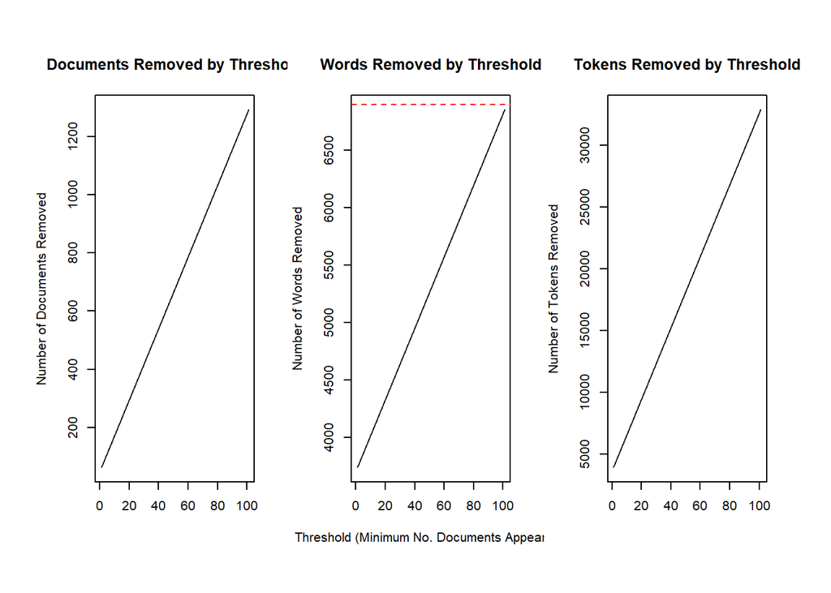

```r
plotRemoved(processed$documents, lower.thresh=seq(1,200, by=100))
```

```r
# keep those words that appear more than 1% in the document corpus
threshold1 <- round(1/100 * length(processed$documents),0)

result1 <- prepDocuments(processed$documents,
                     processed$vocab,
                     processed$meta,
                     lower.thresh = threshold1)
```

```
## Removing 6787 of 6902 terms (25590 of 40090 tokens) due to frequency
## Removing 767 Documents with No Words
## Your corpus now has 4310 documents, 115 terms and 14500 tokens.
```

## 7.2 Number of topics

- Based on the work from [@Lee], we can set K=0 to initialize the algorithm that yield the possible maximum number of topics.

```r
numtopics1 <- stm::searchK(result1$documents,
                           result1$vocab,K=0,
                           prevalence = ~ popularity + comments + shares + love +
                             wow + care + sad + angry + like_haha + anger + joy +
                             trust + hour + image_group,
                           data=result1$meta,heldout.seed = 1) #36
```

- For the numtopics1, the maximum number of topics is 36.
- From the above, let’s explore different Ks.

```r
numtopics1 <- stm::searchK(result1$documents,result1$vocab,K=c(9,18,27),
                           prevalence = ~ popularity + comments + shares + love +
                             wow + care + sad + angry + like_haha + anger + joy +
                             trust + hour + image_group,
                           data=result1$meta,heldout.seed = 1)
```

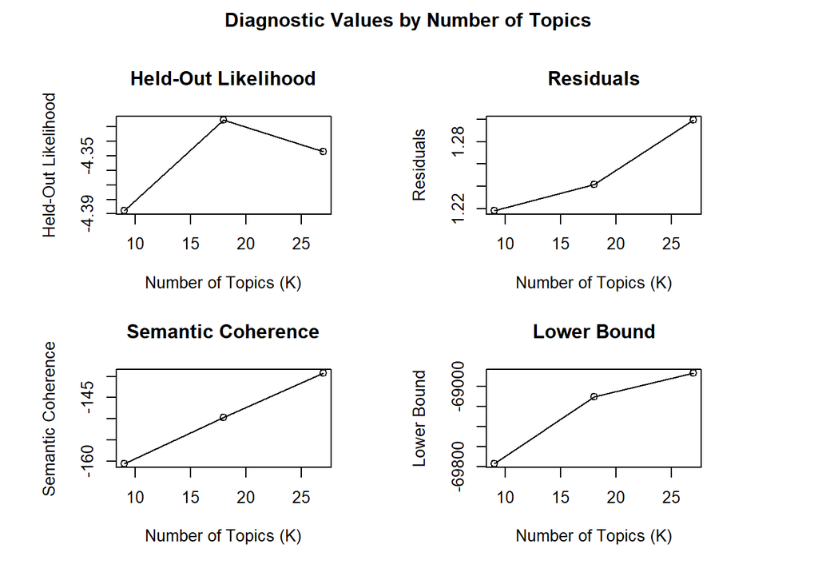

```r
plot(numtopics1) # k = 18
```

- Let’s dig deeper by finding the optimal K from 6 to 21 topics.

```r
numtopics1.1 <- stm::searchK(result1$documents,
                             result1$vocab,
                             K=seq(from=6, to=21, by=3),

                             prevalence = ~ popularity + comments + shares + love +
                             wow + care + sad + angry + like_haha + anger + joy +
                             trust + hour + image_group,

                             data=result1$meta,heldout.seed = 1)
```

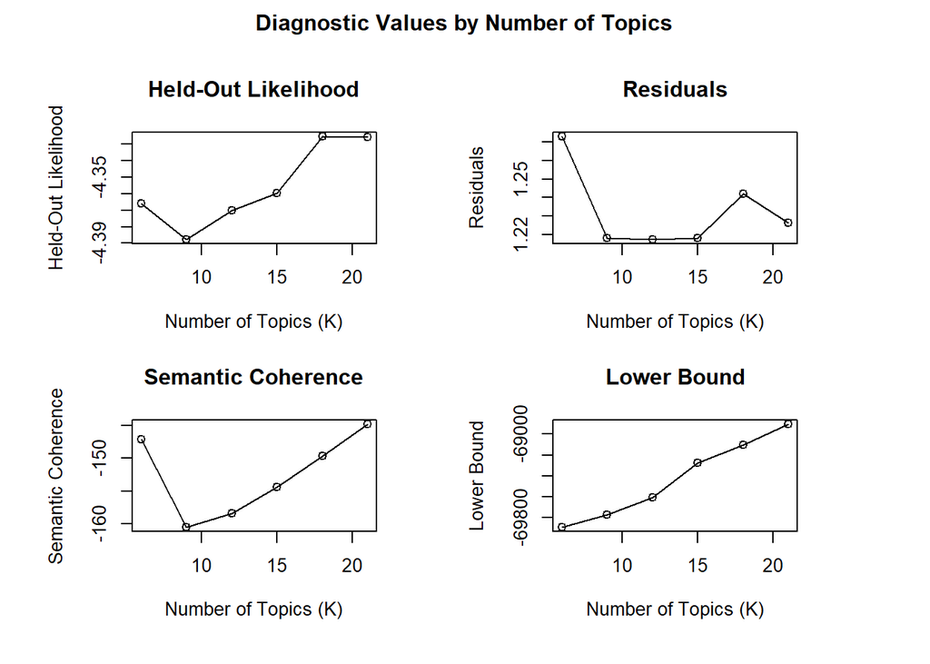

```r
#par(mar=c(1,1,1,1))
plot(numtopics1.1) # k = 21
```

```r
knitr::kable(numtopics1.1$results)
```

| K | exclus | semcoh | heldout | residual | bound | lbound | em.its |
| --- | --- | --- | --- | --- | --- | --- | --- |
| 6 | 9.372374 | -147.1556 | -4.366082 | 1.273193 | -69901.87 | -69895.29 | 49 |
| 9 | 9.523912 | -160.5913 | -4.387726 | 1.218142 | -69783.86 | -69771.06 | 50 |
| 12 | 9.57288 | -158.4882 | -4.369938 | 1.217211 | -69628.9 | -69608.91 | 77 |
| 15 | 9.602568 | -154.4539 | -4.359786 | 1.217856 | -69305.62 | -69277.72 | 100 |
| 18 | 9.606592 | -149.6531 | -4.32518 | 1.241807 | -69142.76 | -69106.36 | 118 |
| 21 | 9.606459 | -144.7675 | -4.325537 | 1.226156 | -68949.69 | -68904.31 | 104 |

## 7.3 Model estimation

- Once we have set the optimal K = 21, we will fit the model and see the relationship of topics to other features.

```r
# fitting stm model using the number of topics (K) = 21 with threshold = 1%
suppressWarnings(library(stm))
finfit1 <- stm::stm(documents = result1$documents,
               vocab = result1$vocab,
               K = 21,
               prevalence = ~ popularity + comments + shares + love +
                             wow + care + sad + angry + like_haha + anger + joy +
                             trust + hour + image_group,
               #max.em.its = 75,
               data = result1$meta,
               reportevery=10,
               gamma.prior = "L1",
               sigma.prior = 0.9,
               init.type = "Spectral",seed = 123)
```

## 7.4 Topic-Document Association

- Let’s explore document-topic association using a summary view of data frame.

```r
topic1_21 <- make.dt(finfit1, result1$meta)
```

## 7.5 Topic Correlation

- Let’s discover the correlation among topics.

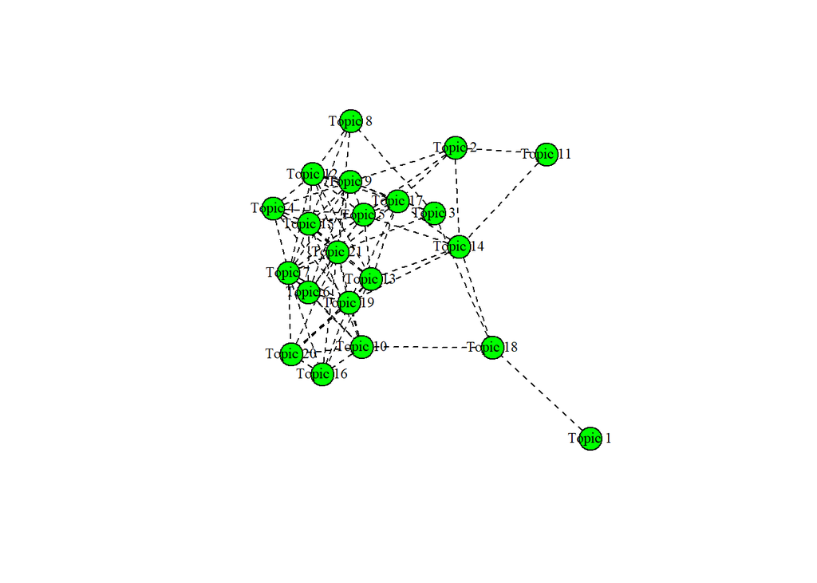

```r
mod.corr <- topicCorr(finfit1)
plot(mod.corr)
```

- All topics are well correlated to each other. However, topic 1 and topic 11 are likely to be exclusive since they have only 1-2 connections (low degree centrality).